# Notebook: Races vs Tournament

```r
# Unconditional parametric [Odds(first) = exp(alpha + beta *
# t )]
fit$logi <- glm(submit_first ~ date, data = z, binomial(logit))
summary(fit$logi)
```

```
##
## Call:
## glm(formula = submit_first ~ date, family = binomial(logit),
##     data = z)
##
## Deviance Residuals:
##     Min       1Q   Median       3Q      Max
## -0.6252  -0.5441  -0.4394  -0.3801   2.3687
##
## Coefficients:
##             Estimate Std. Error z value Pr(>|z|)
## (Intercept) -1.53318    0.18853  -8.132 4.21e-16 ***
## date        -0.15121    0.04614  -3.277  0.00105 **
## ---
## Signif. codes:  0 '***' 0.001 '**' 0.01 '*' 0.05 '.' 0.1 ' ' 1
##
## (Dispersion parameter for binomial family taken to be 1)
##
##     Null deviance: 539.99  on 773  degrees of freedom
## Residual deviance: 528.81  on 772  degrees of freedom
## AIC: 532.81
##
## Number of Fisher Scoring iterations: 5
```

```r
# Unconditional with interaction
fit$logi2 <- glm(submit_first ~ date + date:treatment, data = z,
    binomial(logit))
summary(fit$logi2)
```

```
##
## Call:
## glm(formula = submit_first ~ date + date:treatment, family = binomial(logit),
##     data = z)
##
## Deviance Residuals:
##     Min       1Q   Median       3Q      Max
## -0.6267  -0.5273  -0.4601  -0.3801   2.5737
##
## Coefficients:
##                          Estimate Std. Error z value Pr(>|z|)
## (Intercept)              -1.52808    0.18858  -8.103 5.36e-16 ***
## date                     -0.21835    0.07201  -3.032  0.00243 **
## date:treatmenttournament  0.08546    0.07472   1.144  0.25273
## date:treatmentreserve     0.09344    0.07689   1.215  0.22423
## ---
## Signif. codes:  0 '***' 0.001 '**' 0.01 '*' 0.05 '.' 0.1 ' ' 1
##
## (Dispersion parameter for binomial family taken to be 1)
##
##     Null deviance: 539.99  on 773  degrees of freedom
## Residual deviance: 526.96  on 770  degrees of freedom
## AIC: 534.96
##
## Number of Fisher Scoring iterations: 5
```

```r
# Note the difference when the intercept is not there

# Conditional [Odds(first) = exp(alpha_i + beta * t )]
fit$coclog <- clogit(submit_first ~ date + strata(coder_id),
    data = z)
summary(fit$coclog)
```

```
## Call:
## coxph(formula = Surv(rep(1, 774L), submit_first) ~ date + strata(coder_id),
##     data = z, method = "exact")
##
##   n= 774, number of events= 86
##
##         coef exp(coef) se(coef)      z Pr(>|z|)
## date -0.1340    0.8746   0.0433 -3.095  0.00197 **
## ---
## Signif. codes:  0 '***' 0.001 '**' 0.01 '*' 0.05 '.' 0.1 ' ' 1
##
##      exp(coef) exp(-coef) lower .95 upper .95
## date    0.8746      1.143    0.8034    0.9521
##
## Rsquare= 0.013   (max possible= 0.386 )
## Likelihood ratio test= 9.93  on 1 df,   p=0.001627
## Wald test            = 9.58  on 1 df,   p=0.00197
## Score (logrank) test = 9.81  on 1 df,   p=0.001735
```

```r
# Interactions with treatment dummies [Odds(first) =
# exp(alpha_i + beta_i * t )]
fit$coclog2 <- clogit(submit_first ~ date:treatment + strata(coder_id),
    data = z)
summary(fit$coclog2)
```

```
## Call:
## coxph(formula = Surv(rep(1, 774L), submit_first) ~ date:treatment +
##     strata(coder_id), data = z, method = "exact")
##
##   n= 774, number of events= 86
##
##                              coef exp(coef) se(coef)      z Pr(>|z|)
## date:treatmentrace       -0.27991   0.75585  0.08801 -3.180  0.00147 **
## date:treatmenttournament -0.08726   0.91644  0.06847 -1.274  0.20253
## date:treatmentreserve    -0.06708   0.93512  0.07522 -0.892  0.37256
## ---
## Signif. codes:  0 '***' 0.001 '**' 0.01 '*' 0.05 '.' 0.1 ' ' 1
##
##                          exp(coef) exp(-coef) lower .95 upper .95
## date:treatmentrace          0.7559      1.323    0.6361    0.8982
## date:treatmenttournament    0.9164      1.091    0.8013    1.0481
## date:treatmentreserve       0.9351      1.069    0.8069    1.0837
##
## Rsquare= 0.018   (max possible= 0.386 )
## Likelihood ratio test= 14.16  on 3 df,   p=0.002689
## Wald test            = 12.53  on 3 df,   p=0.005761
## Score (logrank) test = 13.61  on 3 df,   p=0.003487
```

```r
# Note: the above model is the same as clogit(submit_first ~
# date + date:treatment + strata(coder_id), data=z)

# Coefficients
sapply(fit, coef)
```

```
## $clog
##       date
## -0.1510078
##
## $logi
## (Intercept)        date
##  -1.5331826  -0.1512076
##
## $logi2
##              (Intercept)                     date date:treatmenttournament
##              -1.52808481              -0.21835013               0.08545552
##    date:treatmentreserve
##               0.09344282
##
## $coclog
##       date
## -0.1339918
##
## $coclog2
##       date:treatmentrace date:treatmenttournament    date:treatmentreserve
##              -0.27990753              -0.08725850              -0.06707555
```

```r
# Days as factors


# # Compute first submission time time.max <- '2015-03-16
# 11:59:59 EDT' time.min <- '2015-03-08 12:00:00 EDT'
# time.censored <- 192 fsutime <-
# as.numeric(difftime(races.sub$timestamp, time.min ,
# unit='hours')) dat <- with(races.sub, aggregate(fsutime ~
# handle, FUN=min)) dat$fsu <- 1 dat2 <- merge(dat, races,
# by='handle', all=TRUE) dat2$fsu[is.na(dat2$fsu)] <- 0
# dat2$fsutime[is.na(dat2$fsutime)] <- time.censored surv <-
# rep() surv$m1 <- survreg(Surv(fsutime, fsu) ~ 1, dat2,
# dist='weibull', scale=1) surv$m2 <- survreg(Surv(fsutime,
# fsu) ~ treatment + mmevents, dat2 , dist='weibull',
# scale=1) surv$m3 <- survreg(Surv(fsutime, fsu) ~ treatment
# + mmevents, dat2, dist='exponential') surv$tobin <-
# survreg(Surv(fsutime, fsu, type='left') ~ treatment +
# mmevents, data=dat2, dist='gaussian') stargazer(surv,
# type='text') # A model with different baseline survival
# shapes for two groups, i.e., # two different scale
# parameters survreg(Surv(time, status) ~ ph.ecog + age +
# strata(sex), lung) # There are multiple ways to
# parameterize a Weibull distribution. The survreg # function
# embeds it in a general location-scale family, which is a #
# different parameterization than the rweibull function, and
# often leads # to confusion.  # survreg's scale =
# 1/(rweibull shape) # survreg's intercept = log(rweibull
# scale) # For the log-likelihood all parameterizations lead
# to the same value.  y <- rweibull(1000, shape=2, scale=5)
# survreg(Surv(y)~1, dist='weibull') # Economists fit a model
# called `tobit regression', which is a standard # linear
# regression with Gaussian errors, and left censored data.
# tobinfit <- survreg(Surv(durable, durable>0, type='left') ~
# age + quant, data=tobin, dist='gaussian')
```

# Scores

```r
baseline <- 0.792867
target <- 0.817866
winner <- 0.843962
```

The baseline F-score achieved by NIH researchers was 0.792867. We set up a hard-to-reach F-score target for the race competition which was 0.817866 (about a 3 percent increase of the baseline). The winner achieved a score of 0.843962. This represents a 5.1095 percentage points increase compared to the baseline which can be regarded as a very remarkable improvement (more than 6 percent).

Figure below shows the provisional scores over the submission time. The left panel shows the raw scores that are very volitile because some preliminary submissions failed to compile or encountered other issues that either terminated the program resulting in a zero or lead to very low scores. This high volatility, however, does not reflect genuine variation in the quality of submissions. The right panel shows the scores capped from [below to reduce volatility due to experimentation with imperfect solutions].

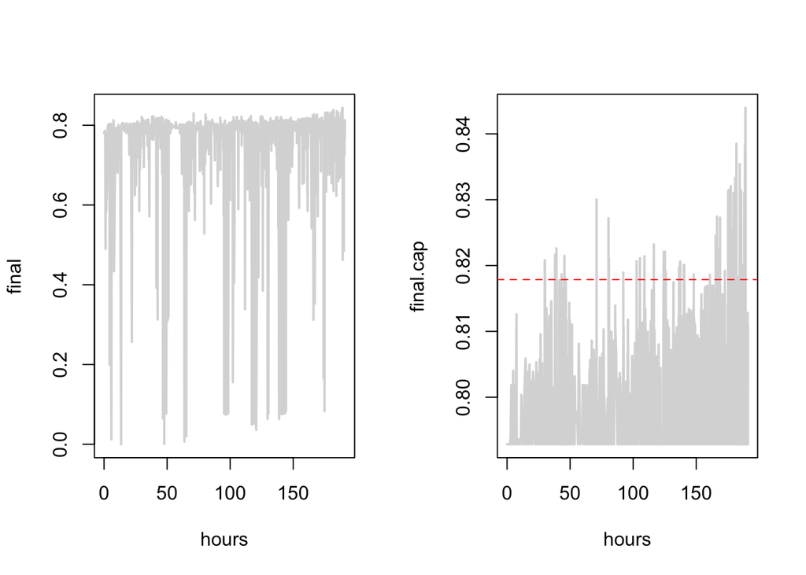

```r
# Load libraries
require(races)
require(stargazer)
# require(mgcv) require(arm)

# Load Data
data(races)
data(scores)

# Merge
dat <- merge(scores, races[, c("coder_id", "treatment", "room")],
    by = "coder_id")
dat <- dat[order(dat$timestamp), ]

attach(dat)
provisional <- provisional/1e+06
final <- final/1e+06
hours <- as.numeric(difftime(timestamp, min(timestamp), unit = "hours"))

# New variable
last_submission <- ave(submission, coder_id, FUN = max)
provisional.cap <- ifelse(provisional < baseline, baseline, provisional)
final.cap <- ifelse(final < baseline, baseline, final)


# General plot
par(mfrow = c(1, 2))
plot(aggregate(final ~ hours, FUN = mean), type = "l", lwd = 2,
    col = gray(0.85))
plot(aggregate(final.cap ~ hours, FUN = mean), type = "l", lwd = 2,
    col = gray(0.85))
abline(h = target, lty = 2, col = 2)
```

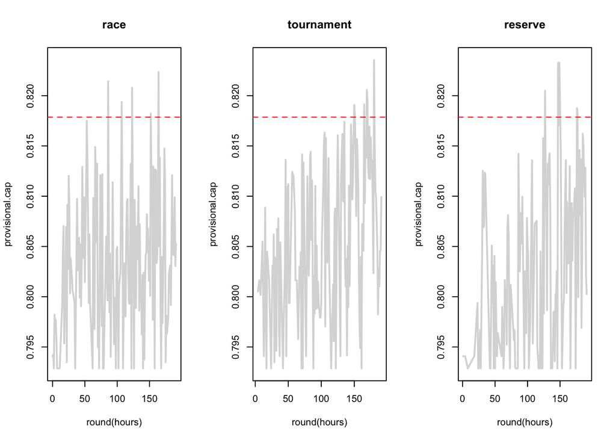

```r
# Add winner dots

winners <- function() {
    out <- matrix(ncol = 2, nrow = 3)
    rownames(out) <- levels(treatment)
    colnames(out) <- c("hour", "final")
    w <- head(which(final > target & treatment == "race"), 1)
    out[1, ] <- c(hours[w], final[w])
    final.max <- tapply(final, treatment, FUN = max, na.rm = TRUE)
    w <- which(final == final.max["tournament"])
    out[2, ] <- c(hours[w], final[w])
    w <- which(final == final.max["reserve"])
    out[3, ] <- c(hours[w], final[w])
    out
}
# points(winners())

# By treatment
x <- aggregate(provisional.cap ~ round(hours) + treatment, FUN = mean)
index <- split(1:nrow(x), x[, 2])
par(mfrow = c(1, 3))
for (i in 1:3) {
    plot(x[index[[i]], -2], ylim = range(x[, 3]), type = "l",
        lwd = 2, col = gray(0.85))
    title(names(index)[i])
    abline(h = target, lty = 2, col = 2)
}
```

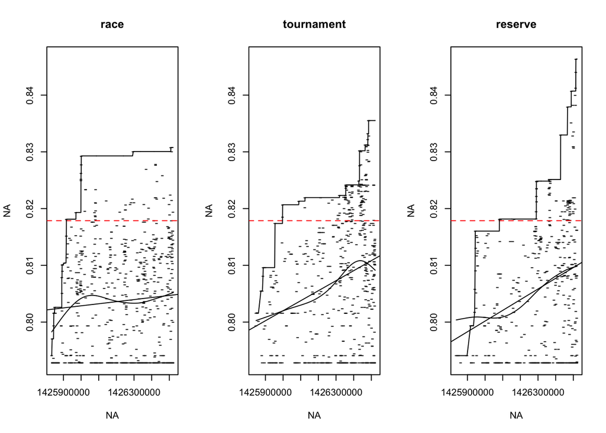

```r
# plot(aggregate(provisional.cap ~ round(hours), FUN=mean),
# type='l', lwd=2, col=gray(.85))
# points(aggregate(provisional ~ round(hours), FUN=mean))


# By treatment
i <- split(1:nrow(dat), treatment)
xlim <- range(timestamp)
ylim <- range(provisional.cap)

max.score <- function(x) {
    n <- length(x)
    y <- numeric(n)
    for (i in 1:n) y[i] <- max(x[1:i])
    return(y)
}


plot.scores <- function(index, add = FALSE, ...) {
    x <- timestamp[index]
    y <- provisional.cap[index]
    if (add == FALSE)
        plot(NA, NA, xlim = xlim, ylim = ylim)
    points(x, y, pch = "-", ...)
    abline(h = target, lty = 2, col = 2)
    lines(smooth.spline(x, y, df = 4))
    abline(lm(y ~ x))
    lines(x, max.score(y))
}

par(mfrow = c(1, 3))
for (k in levels(treatment)) {
    plot.scores(i[[k]])
    title(k)
}
```

[output not shown]

[output cut: 16 more lines]

[output not shown]

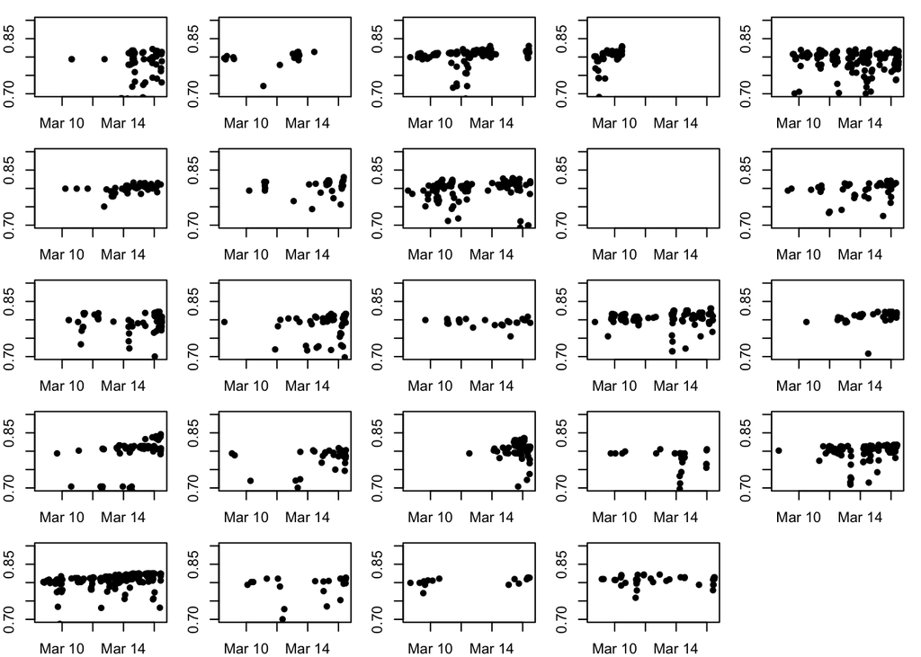

```r
# submission.cap <- ifelse(submission>15, 15, submission)
# boxplot(provisional/1e6 ~ submission.cap, pch='-')
# abline(h=0.8, col=2)

# Time series
l <- split(dat, paste(treatment, room))
xlim <- range(timestamp)
ylim <- c(0.7, 0.9)
par(mfrow = c(5, 5), mar = c(2, 2, 1, 1))
sapply(l, function(x) plot(x$timestamp, x$provisional/1e+06,
    xlim = xlim, ylim = ylim, pch = 16))
```

# Model estimation

- We observe $Y_1, ..., Y_L$ participants for $(l=1, ..., L)$ rooms
- Each room has $n_l$ registered competitors and room characteristcs $X_l$ (deadline, target, etc.).
- We assume that $Y_l$ is distributed as a binomial variable with parameters $n_l$ and $p(x_l, \theta)$ where $p(x, \theta)$ describes the probability for a competitor to participate in a room described by the vector $x$:

$$\begin{equation}
\label{model}
Y_{l} \sim \text{Binomial}(N_l, p(x_l, \theta)) \quad \text{for each } l=1,...,L.
\end{equation}$$

$$R(a; F_l) = C(a, y_{0,l}, t_{0,l})$$

- Given $F_l(\cdot)$ the distribution of individual abilities in each room, the probability of entry is:

$$\begin{equation}
p(x_l, \theta) = 1 - F_l(a_{0l})
\end{equation}$$

First, we rewrite the probability $p(x, \theta)$ in the following way:

$$p(x_l, \theta) = 1 - \theta_1 x_l^{\theta_2}$$

where we denote the (observed) target by $x_l$ and the vector of parameters by $\theta=(\theta_1, \theta_2)$ where $\theta_1 \equiv m_l^{\alpha/(n_l-1)}$ and $\theta_2 \equiv \beta/(n_l-1)$. Assume that $n_l=n$ for each $l=1,...,L$.

Let $Y_1, Y_2, ..., Y_L$ be the count of participants generated by our binomial-distribution model. The likelihood is:

$$\mathcal{L} = \prod_{l=1}^L \binom{n_l}{y_l} p(x_l, \theta)^{y_l} [1-p(x_l, \theta)]^{n_l - y_l}$$

The log-likelihood is:

$$ll = \sum_{l=1}^L y_l\log(p(x_l, \theta)) + (n_l - y_l) \log(1-p(x_l, \theta))$$

where we omit the binomial coefficient as it is a constant that does not affect estimation.

Using our model into the aboev eqution:

$$ll = \sum_{l=1}^L y_l\log(1 - \theta_1 x_l^{\theta_2})
+ (n - y_l) [\log(\theta_1) + \theta_2\log(x_l)]$$

Let the summation be denoted by $\sum y_l = \bar y$. We can rewrite the ll expression:

$$ll = (L n - \bar y)\log(\theta_1) + \sum_{l=1}^L y_l\log(1 - \theta_1 x_l^{\theta_2})
+ (n - y_l) \theta_2\log(x_l)$$

First order conditions are:

$$\frac{\partial ll}{\partial \theta_1}
= \frac{(L n - \bar y)}{\theta_1}
- \sum_{l=1}^L y_l \frac{x_l^{\theta_2}}{1 - \theta_1 x_l^{\theta_2}} = 0$$

$$\frac{\partial ll}{\partial \theta_2}
= \sum_{l=1}^L \left[- y_l \frac{x_l^{\theta_2}\theta_1 \log(x_l)}{1 - \theta_1 x_l^{\theta_2}}
+ (n - y_l) \log(x_l) \right]= 0.$$

Try with simulations

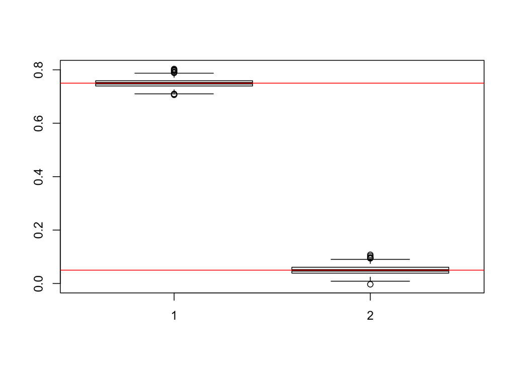

```r
n <- 10
nsize <- 199
theta1 <- 0.75
theta2 <- 0.05
params <- c(theta1, theta2)
x <- runif(nsize)
p <- 1 - theta1 * x^theta2
# hist(prob, 100)

loglik <- function(theta, data) {
    theta1 <- theta[1]
    theta2 <- theta[2]
    x <- data$x
    y <- data$y
    n <- data$n
    p <- 1 - theta1 * x^theta2
    out <- dbinom(y, n, p, log = T)
    return(-sum(out))
}

# Simulate data
y <- rbinom(nsize, size = n, prob = p)

# Example: loglik(c(0.5, 0.9), data.frame(y, x, n))

# MLE estimation
dat <- data.frame(y, x, n)
theta.start <- runif(2)
mle.est <- optim(theta.start, loglik, data = dat)
thetahat <- mle.est$par

# Replications
out <- replicate(1000, {
    y <- rbinom(nsize, size = n, prob = p)
    dat <- data.frame(y, x, n)
    mle.est <- optim(theta.start, loglik, data = dat)$par
})
boxplot(t(out))
abline(h = params, col = 2)
```

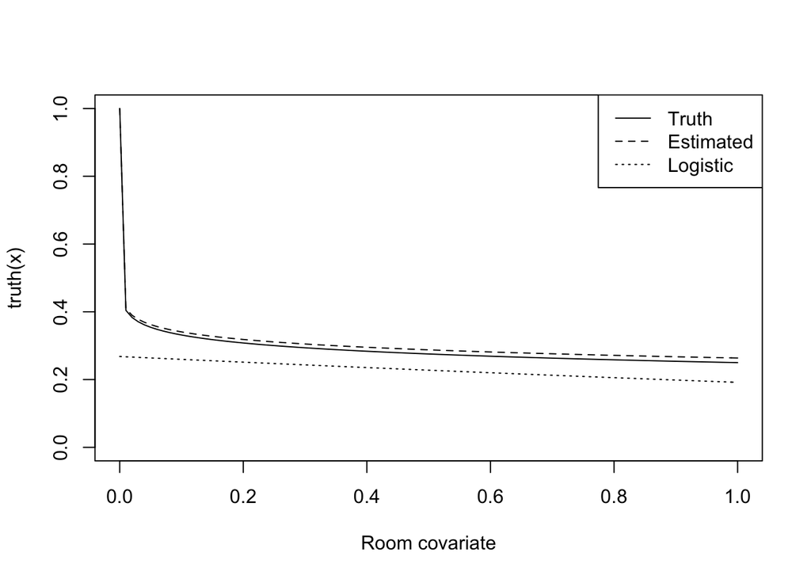

```r
truth <- function(x) 1 - params[1] * x^params[2]

# Now I can 'predictions' on what would happen with different
# 'x' distribution
prediction <- function(x) 1 - thetahat[1] * x^thetahat[2]

# Compare with logistic regression
N <- rep(n, nsize)
logistic <- glm(cbind(y, N) ~ x, family = binomial(logit))
prediction.logistic <- function(x) {
    yhat <- coef(logistic)[1] + coef(logistic)[2] * x
    exp(yhat)/(1 + exp(yhat))
}

# FIGURE
curve(truth, xlab = "Room covariate", ylim = c(0, 1))
curve(prediction, add = TRUE, lty = 2)
curve(prediction.logistic(x), add = TRUE, lty = 3)
legend("topright", c("Truth", "Estimated", "Logistic"), lty = 1:3)
```

# Identification (old)

## Example with the Uniform distribution

Imagine that the distribution $F_\theta$ is uniform on $(0, \theta)$ and the cost ability $c_a(x) = 1/x$. Then the zero profit condition becomes

$$\begin{align}
\left(\frac{m}{\theta}\right)^{n-1} m = \beta x_l
\end{align}$$

Solving for the marginal type gives:

$$\begin{align}
m = \left(\beta x_l \theta^{n-1}\right)^{1/n}
\end{align}$$

So, the probability of participation becomes

$$\begin{align}
p(x_l, \theta)
& = 1 - F_\theta(m) \\
& = 1 - \frac{\left(\beta x_l \theta^{n-1}\right)^{1/n} }{\theta} \\
& = 1 - \left(\frac{\beta x_l}{\theta}\right)^{1/n}.
\end{align}$$

Because it is non-linear in its parameters, the model is not identifiable [need proof]. However, we can re-parametrize the model with $\beta/\theta \equiv \eta$ to make the parameter $\eta$ identifiable.

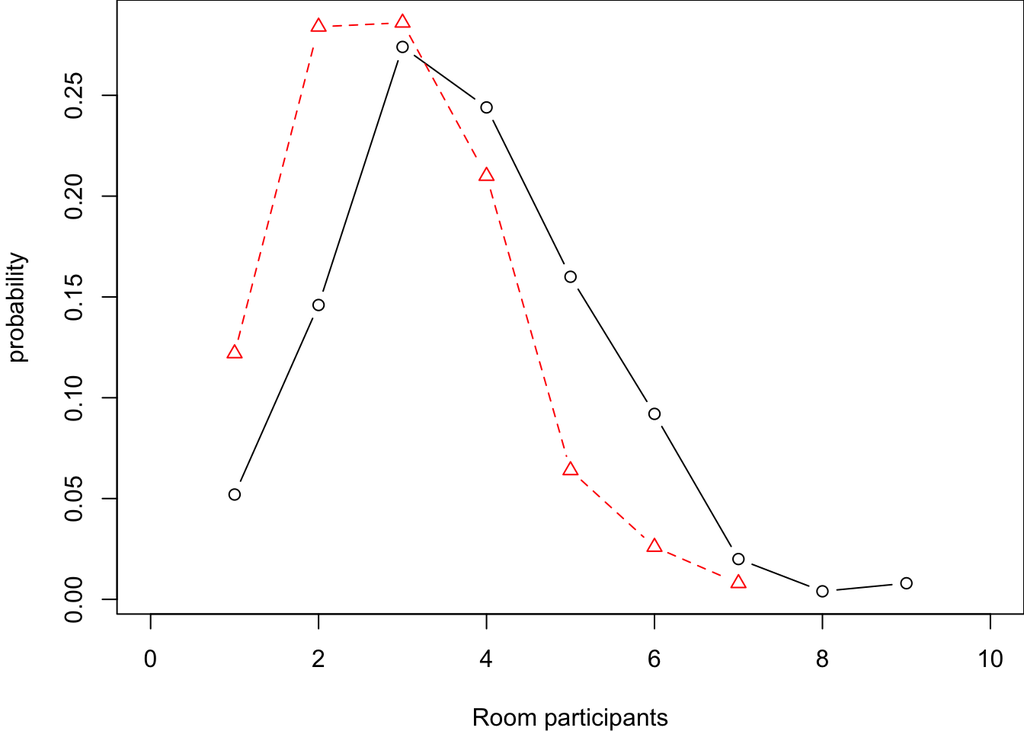

Simulated distribution of participants with uniform distribution. Parameters are $\eta=0.1$ and $n=15$. Data simulated 500 times. Dashed curve had higher costs ($x_l=1.5$) than the solid curve ($x_l=0.5$).

## Estimation

Our aim is to estimate the parameters $\theta$ and $\beta$ and to evaluate whether costs are different between the three competition modes under study: race, tournament, tournament + requirement.

The deviance is:
$$\begin{equation}
D(\theta) = -2 \sum Y \log (\frac{N p(x, \theta)}{Y})
+ (N - Y) \log ( \frac{N - N p}{N - Y}).
\end{equation}$$

```r
# Define likelihood
structreg <- function(x, y, wt = rep(1, length(y)), intercept = TRUE,
    start = rep(0, p), ...) {
    fmin <- function(beta, X, y, w) {
        p <- 1 - (beta %*% X)^(1/n)  # Function of parameters
        -sum(2 * w * ifelse(y, log(p), log(1 - p)))
    }
    # gmin <- function(beta, X, y, w) { # Gradient here!  }
    if (is.null(dim(x)))
        dim(x) <- c(length(x), 1)
    dn <- dimnames(x)[[2]]
    if (!length(dn))
        dn <- paste("Var", 1:ncol(x), sep = "")
    p <- ncol(x) + intercept
    if (intercept) {
        x <- cbind(1, x)
        dn <- c("(Intercept)", dn)
    }
    if (is.factor(y))
        y <- (unclass(y) != 1)
    # fit <- optim(start, fmin, gmin, X = x, y = y, w = wt,
    # method = 'BFGS', ...)
    fit <- optim(0.5, fmin, X = x, y = y, w = wt, method = "BFGS",
        ...)
    names(fit$par) <- dn
    cat("\nCoefficients:\n")
    print(fit$par)
    cat("\nResidual Deviance:", format(fit$value), "\n")
    cat("\nConvergence message:", fit$convergence, "\n")
    invisible(fit)
}

# Create data
ilogit <- function(x) exp(x)/(1 + exp(x))
n <- 50000
competitors <- 5
x1 <- rchisq(competitors, df = 3)
x2 <- runif(n)
x3 <- rnorm(n)
X <- cbind(rep(1, length(x1)), x1, x2, x3)
betas <- c(-2.5, 0.1, 0.25, 0.5)
fc <- ilogit(X %*% betas)  ## This the fixed cost
p <- 1 - fc^(1/competitors)
y <- rbinom(n = n, size = competitors, prob = p)

# Objective function
fmin <- function(beta, X, y, w, competitors) {
    p <- 1 - ilogit(X %*% beta)^(1/competitors)  # Function of parameters
    -sum(2 * w * ifelse(y, log(p), log(1 - p)))
}

b.start <- runif(length(betas))
(out <- optim(b.start, fmin, X = X, y = y, competitors = competitors,
    w = rep(1, length(y)))$par)
```

```
## [1] -12.5660559   0.4217197   0.7780973   2.0821769
```

```r
rbind(out/competitors, betas)
```

```
##            [,1]       [,2]      [,3]      [,4]
##       -2.513211 0.08434395 0.1556195 0.4164354
## betas -2.500000 0.10000000 0.2500000 0.5000000
```

## More examples

Suppose F is lognormal($\mu, \sigma$), then the zero profit condition is:

$$\begin{align}
\left[\frac 12 +\frac 12 \left(\frac{\log{m}-\mu}{\sqrt{2\sigma}}\right)\right] = a^{-1/(n-1)} K_l
\end{align}$$

```
# xxx
zeroprofit <- function(x, mu, sigma, n) {
    x * plnorm(x, meanlog=mu, sdlog=sigma)^(n-1)
}
for (i in 3:10)
    curve(zeroprofit(x, i, 10, 10), add=TRUE, lty=i)
```

```r
# Clear
rm(list = ls())

# Libraries
require(xtable)
require(moments)
require(races)

# Data
data(races)
attach(races)

# TABLE 1.
size <- ave(submit, paste(treatment, room), FUN = length)
(m <- aggregate(submit ~ room + size + treatment, FUN = sum))
```

```
##    room size  treatment submit
## 1     1    9       race      2
## 2     2   10       race      2
## 3     3   10       race      5
## 4     4   10       race      1
## 5     5   15       race      4
## 6     6   15       race      3
## 7     7   15       race      4
## 8     8   15       race      5
## 9     1   10 tournament      3
## 10    2   10 tournament      5
## 11    3   10 tournament      5
## 12    4   10 tournament      2
## 13    5   15 tournament      5
## 14    6   15 tournament      4
## 15    7   15 tournament      4
## 16    8   15 tournament      5
## 17    1   10    reserve      1
## 18    2   10    reserve      3
## 19    3   10    reserve      3
## 20    4   10    reserve      2
## 21    5   15    reserve      4
## 22    6   15    reserve      6
## 23    7   15    reserve      3
## 24    8   15    reserve      5
```

# The model

We now generalize the contest game introduced by @moldovanu2001optimal to a situation where players simultaneously decide $i)$ the quality and $ii)$ how fast to produce a given output. Then we explore the problem of revenue maximization faced by a contest designer with preferences for both quality and time.

## Equilibrium

In this section, we solve the model for the unique symmetric Bayesian Nash equilibrium of players.

### Tournament

At equilibrium, players choose $\quality$ and $t_i$ by maximizing given their beliefs about the equilibrium actions of the other players.

The key to characterization of the equilibrium is that $t_i=\deadline$ is a (weakly) dominant strategy for each player. Indeed, any time strictly below the deadline does not affect the probability of winning but is costly in terms of effort, and any time strictly above the deadline gives a negative payoff.

Since players should avoid playing weakly dominated strategies, we have that $t_i=\deadline$ for every $i=1,...,n$. Then it can be shown that, at equilibrium, the optimal quality is a one-to-one transformation of a player’s ability according to some “bidding” function $b(\cdot)$. Hence, $Y_i = b(A_i)$. Since the distribution of $A_i$ is known, one can use a change of variables formula to express the probability of winning in in terms of the distribution $F$. Then, the first order condition of $\pi$ with respect to quality gives the following differential equation in $\ability$ (for every $i=1,...,n$):

$$\sum_{k=1}^{q} \hat p^\prime_{k}(\phi(y_i)\mid \tournament) \phi^\prime(y_i) v_k
= \beta y_i^{\beta-1} a^\alpha t^\gamma$$

with the boundary condition $y(\lotype)=0$.

At equilibrium we have $a=\phi(y)$. Thus, the differential equation is separable. After rearranging, we have:

$$\sum_{k=1}^{q}\phi(y_i)^{-\alpha}\hat p^\prime_{k}(\phi(y_i)\mid \tournament)\phi^\prime(y_i) v_k
= \beta y_i^{\beta-1} t^\gamma.$$

Integration of both sides with respect to $\phi$ gives:

$$\int_{0}^{y}
\sum_{k=1}^{q} t^{-\gamma} v_k
\phi(x)^{-\alpha}\hat p^\prime_{k}(\phi(x)\mid \tournament)\phi^\prime(x) dx
= \int_{0}^{y} \beta x^{\beta-1} dx$$

Using the chain rule of derivatives

$$\int_a^b f(g(x)) g^\prime(x) dx = \int_{g(a)}^{g(b)} f(x) dx \qquad \text{(chain rule)}$$

the solution is

$$\begin{equation}
\label{optimal quality tournament}
y(a_i) =
\left[\deadline^{-\gamma} \sum_{k=1}^q v_k \int x^{-\alpha} \hat p^\prime_k(x)dx \right]^{1/\beta}
\end{equation}$$

$$y(\hitype) =
\left[\deadline^{-\gamma} v_1 \left(
\frac{\hitype^{-\alpha+1} - \lotype^{-\alpha+1}}{-\alpha + 1}
\right)\right]^{1/\beta}.$$

- Monotonicity of the equilibrium output quality implies that, for every $i=1, ..., n$, the equilibrium expected payoff from the contest $\pi_i^*$ depends on the rank of the player’s ability relative to the others.
- Equilibrium payoffs do not depend on the elasticity $\beta$ or $\gamma$, but only on $\alpha$.
- When abilities are distributed over the unit interval, the equilibrium payoff for the highest ability player is $\pi(\hitype=1) = v_1 (-\alpha)/ (1-\alpha)$.

### Equilibrium in a race

In a similar way, one can derive the equilibrium strategy in a race. Again the key observation is that any quality below the target gives a zero probability of winning and any quality above the target gives a constant probability of winning. Thus, player $i$’s choice of quality is either zero (with $t_i=\deadline$ by convention) or $y_i=\target$.

### Tournament vs races

Let’s make an example.

```
p <- plnorm   # pdf individual abilities
r <- rlnorm   # Simulate individual abilities
cy <- function(x) x^2 # Cost function performance
ct <- function(x) 2*exp(1-x)  # Cost function timing
```

## The contest designer’s problem

Let us now focus on the contest designer’s problem. Imagine the contest designer can choose the competition format to be either the race or the tournament. Imagine all other aspects of design are given. The prize structure $\alpha$ has been already chosen. There is a deadline $\deadline$, which is the same in both competition formats. [The quality requirement $\target^c$ in the tournament is smalle than that in the race $\target^\race > \target^\tournament$)] We will relax this assumption later to consider a more general setting where these variables are also part of the contest designer’s problem.

The contest designer has an objective function that is increasing in the expected quality of the winning solution and decreasing in the corresponding time to completion. Here, to do not complicate exposition, we assume that the contest designer cares about the winning submission only: second placed efforts are not considered. [If the principal values the diversity of the solutions … but we assume it does not.]

Proof. In a tournament, the objective function is
$$\begin{align}
R_\tournament & = \Pr(t_{(1:n)}\leq \deadline) \left\{\int y^*(x \mid t_{(1:n)}\leq \deadline) dF_{n:n}(x) - \tau \deadline - 1 \right\} \nonumber\\
& = \int_{\mtype}^{\hitype} y^*(x) dF_{n:n}(x) - \tau \deadline - 1.
\end{align}$$

That is, the contest designer’s objective function is the sum of the expected output quality for a given deadline, minus the cost $\tau$ of having the winner working on the task until completion (i.e., until the deadline), and the cost of the prize pool (recall the prize pool is normalized to one).

[Implicitly, you’re assuming that the prize is always large enough to ensure positive effort.] [Second prize too is stochastic!!!!]

In a race, the objective function is
$$\begin{align}
R_\race & =
\Pr(a_{(N)}\geq \mtype) \left\{\target - \alpha -
\Pr(a_{(N-1)}\geq \mtype) (1-\alpha) \right\}
- \tau \int_{\mtype}^{\infty} t^*(x) dF_{N:N}(x) \nonumber\\
& = [1-F_{N:N}(\mtype)] \left\{\target - \alpha -
[1-F_{N-1:N}(\mtype)] (1 - \alpha) \right\}
- \tau \int_{\mtype}^{\infty} t^*(x) dF_{N:N}(x).
\end{align}$$
Note. $t^*(x) \leq \deadline$ for all $x$’s. Thus, a lower bound for the above objective function can be computed:
$$\begin{align}
\underline {R_\race} & =
[1-F_{N:N}(\mtype)] \left\{\target - \alpha -
[1-F_{N-1:N}(\mtype)] (1 - \alpha) - \tau \deadline\right\}
\end{align}$$

Note. $y^*(x)$ is lower than $\target$ for all $a < \mtype$. Thus, a lower bound of the tournament’s expression is
$$\begin{align}
\overline {R_\tournament} & =
[1-F_{N:N}(\mtype)] \target + \int_{\mtype}^\infty y^*(x) dF_{N:N}(x)
- \tau \deadline - 1.
\end{align}$$
$$\begin{align}
\underline {R_\race} \geq & \overline {R_\tournament} \nonumber\\
[1-F_{N:N}(\mtype)] (\target - 1 - \tau \deadline) \geq &
[1-F_{N:N}(\mtype)] \target + \int_{\mtype}^\infty y^*(x) dF_{N:N}(x)
- \tau \deadline - 1 \nonumber\\
- [1-F_{N:N}(\mtype)] (\tau\deadline + 1) \geq &
\int_{\mtype}^\infty y^*(x) dF_{N:N}(x)
- (\tau \deadline + 1) \nonumber\\
F_{N:N}(\mtype) (\tau \deadline + 1) \geq &
\int_{\mtype}^\infty y^*(x) dF_{N:N}(x) \nonumber\\
\tau \geq &
\left[
\frac{\int_{\mtype}^\infty y^*(x) dF_{N:N}(x)}{F_{N:N}(\mtype)} -1
\right] \frac{1}{\deadline}
\end{align}$$

End proof.